# Industrial Capabilities

# Industrial Capabilities

> What you make is what you know

## Industrial Capabilities

- Core concepts:
  - a country makes (or does) what it knows
  - products (or activities) represent combinations of knowledge
- Capabilities are like letters in Scrabble
  - The more you have, the more words you can make
  - Rare letters create words worth more points

## Products Embody Knowledge

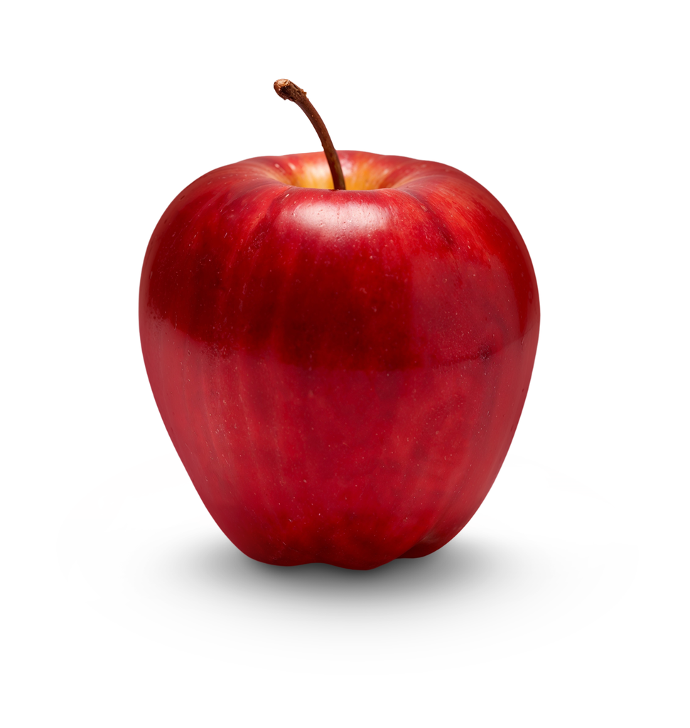

An apple in the supermarket represents:

- Horticulture
- Pest control
- Refrigeration
- Logistics

## Products Embody Knowledge

[figure not shown]

An iPhone represents:

- Semiconductors
- Software/Hardware Engineering
- Materials science
- Lenses
- Marketing
- Packaging

## Measuring Industrial Capabilities

- Export data reveals what a country makes
- Comparison between countries reveals which capabilities are common, and which are rare
- The presence of different capabilities in different countries allows a ranking called the Economic Complexity Index

## Why Does It Matter?

- The Economic Complexity Index is predictive of the direction of future economic growth.
  - Countries with higher complexity are predicted to grow faster
- Useful tool to identify productive capabilities of a country.
- Can be used to identify future opportunities and direct strategy.

## Why Does It Matter to Australia?

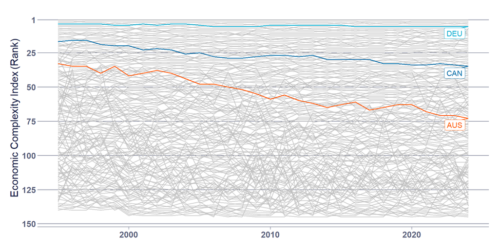

## Why Does it Matter to South Australia?

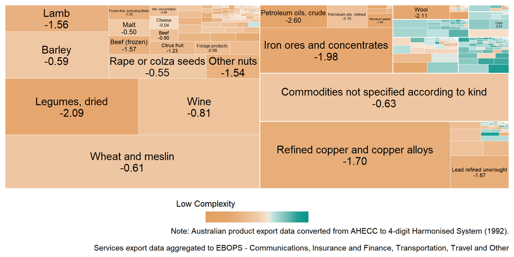

## What Can Be Done?

- Recognise that there is a problem.
- The lack of sufficient existing capabilities requires explicit and direct industrial policy.
- Understand the connection between just transition, decarbonisation, and reindustrialisation.
- Develop a policy agenda which explicitly outlines existing and future opportunities, and how to get there.

## The AMWU and a Future Made in Australia

- The Future Made in Australia Act is a $22.7 billion investment into restoring an industrial base in Australia.
- FMIA, which is public money, must be used to create secure, high-quality jobs. Not subsidise worker exploitation.
- The AMWU is calling for the establishment of a manufacturing council, and tying strong conditions to businesses receiving public money

## Conditions for Employers

- Guarantee of secure jobs, fair wages, and safe conditions
- Collective bargaining as a requirement at workplaces who receive public money.
- Use the state’s power in procurement to support local industry through local content targets.
- Mandate apprentice participation

## Manufacturing Competitiveness Council

- Tripartite Manufacturing Competitiveness Council - with genuine union representation.
- Ensure that all decisions about capital investment, skills, and industry strategy are made with worker input.
- Establish and plan for the orderly transition of our economy - guided by human need, not market whims.

## Fair Trade

- Empower the Anti-Dumping Commission
- Unfair trade, particular dumping, has significant negative effects on local industry. Especially in a country that is seeking to re-industrialise.
- Establish an Independent Advocate for Fair Trade.

## Nationalising Strategic Infrastructure

- Infrastructure that is “too big to fail” or needed “in the national interest” can not be left in the hands of profit maximisers.
- Perpetual bailouts and subsidies
- Natioanalisation can help us to achieve our strategic goals.